# Welcome and Chapter 1

Ann Cannon

Cornell College  
STA 363 Fall 2026 Block 1

# Welcome!

## Instructor

- Dr. Ann Cannon: acannon@cornellcollege.edu

## Course logistics

- Course Dates: August 24th to September 16th
- Course sessions: Daily, 9am-11am and 1pm-3pm; No class second Wednesday afternoon
- Exam Dates: due on September 2nd and September 16th

## What we’re covering this block (1/3)

**Generalized Linear Models (Ch 1 - 6)**

- Introduce models for non-normal response variables
- Estimation, interpretation, and inference
- Mathematical details showing how GLMs are connected

## Generalized Linear Models

*In statistics, a generalized linear model (GLM) is a flexible generalization of ordinary linear regression. The GLM generalizes linear regression by allowing the linear model to be related to the response variable via a link function and by allowing the magnitude of the variance of each measurement to be a function of its predicted value.*

**Logistic regression**

$$\begin{aligned}\pi = P(y = 1 | x) \hspace{2mm} &\Rightarrow \hspace{2mm} \text{Link function: } \log\big(\frac{\pi}{1-\pi}\big) \\
&\Rightarrow \log\big(\frac{\pi}{1-\pi}\big) = \beta_0 + \beta_1~x\end{aligned}$$

[Wikipedia](https://en.wikipedia.org/wiki/Generalized_linear_model)

## What we’re covering this block (2/3)

**Modeling correlated data (Ch 7 - 9)**

- Introduce multilevel models for correlated and longitudinal data
- Estimation, interpretation, and inference
- Mathematical details, particularly diving into covariance structures

## What we’re covering this block (3/3)

**More Regression Models (ITSL Chapter 7)** - Polynomial Regression - Regression Splines - Smoothing Splines - Generalized Additive Models (GAMS)

## What background is assumed for the course?

**Pre-reqs**

- STA 201, 202 and DSC 223

**Background knowledge**

- Statistical content
  - Linear and logistic regression
  - Statistical inference
  - Basic understanding of random variables
- Computing
  - Using R for data analysis
  - Writing reports using R Markdown or Quarto

## Course Toolkit (1/2)

- **Website**
  - https://annrcannon.github.io/Regression2026/
  - Central hub for the course
  - Notes
  - Labs

## Course Toolkit (2/2)

- **Moodle**:
  - https://moodle.cornellcollege.edu/course/view.php?id=9443
  - Submissions
  - Announcements
- **R Server**:
  - http://turing.cornellcollege.edu:8787/
  - Datasets
  - Quarto file storage

## Class Meetings

- Lecture
- Individual and group labs
- Mini-projects
- Exams
- Bring a fully-charged laptop

**Attendance is expected (if you are healthy!)**

## Textbook

[figure not shown]

*Beyond Multiple Linear Regression* by Paul Roback and Julie Legler

- Available [online](https://bookdown.org/roback/bookdown-BeyondMLR/)
- Hard copies available for purchase

## Textbook 2

The secondary text is: [An Introduction to Statistical Learning with Applications in R](https://hastie.su.domains/ISLR2/ISLRv2_corrected_June_2023.pdf.download.html) by Gareth James, Daniela Witten, Trevor Hastie, and Robert Tibshirani – it is freely available online. Chapter 7.

- Hard copies available for purchase

## Using R / RStudio

- RStudio Server is installed and should be used
- http://turing.cornellcollege.edu:8787/

## Activities & Assessments

**Readings**

- Primarily from *Beyond Multiple Linear Regression*
- Recommend reading assigned text before lecture

**Homework** - Primarily from *Beyond Multiple Linear Regression*

- Individual assignments
- Work together but must complete your own work. Discuss but don’t copy.

## Activities & Assessments

**Mini-projects**

- Mini-project 01: Focused on logistic regression models
- Mini-project 02: Focused on models for response variables that represent count data
- Mini-project 03: Focused on data collected at multiple levels
- Short write up and short presentation
- Team-based

## Exams

- Two exams this block, due on September 2nd and September 16th.
- Each will have two components
  - Component 1 will be on these dates and will be a closed-book, closed-note, in-class exam.
  - Component 2 will be a take-home, open-book, open-note exam.
  - You will have 12 hours or more to complete the second component.

## Grading

Final grades will be calculated as follows

| Category | Points |
| --- | --- |
| Homework | 300 |
| Labs & Participation | 75 |
| Mini Projects | 225 |
| Exams | 400 |
| Total | 1000 |

See Syllabus on [website](https://annrcannon.github.io/Regression2026/) for letter grade thresholds.

## Resources

# Chapter 1 - Linear Regression Review

## Setup - R Packages

```r
library(tidyverse)
library(tidymodels)
library(latex2exp)
library(GGally)
library(knitr)
library(patchwork)
library(viridis)
library(ggfortify)
library(tailor)
derby <- read_csv("data/derbyplus.csv")
```

## Simple linear regression

Simplest case

$X=$ explanatory variable

$Y=$ response variable

Both variables are quantitative

Model

$Y_i = \beta_0 + \beta_1 x_i + \epsilon_i$ where $\epsilon_i \sim N\left( 0,\sigma^2\right)$

### Note

The book uses $\sigma^2$ in this notation, not $\sigma$ as we did in STA 201 and STA 202

## Assumptions for linear regression

What are the assumptions for linear regression? . . .

**L**inearity: Linear relationship between mean response and predictor variable(s)

**I**ndependence: Residuals are independent. There is no connection between how far any two points lie above or below regression line.

**N**ormality: Response follows a normal distribution at each level of the predictor (or combination of predictors)

**E**qual variance: Variability (variance or standard deviation) of the response is equal for all levels of the predictor (or combination of predictors)

**Use residual plots to check that the conditions hold before using the model for statistical inference.**

## Assumptions for linear regression

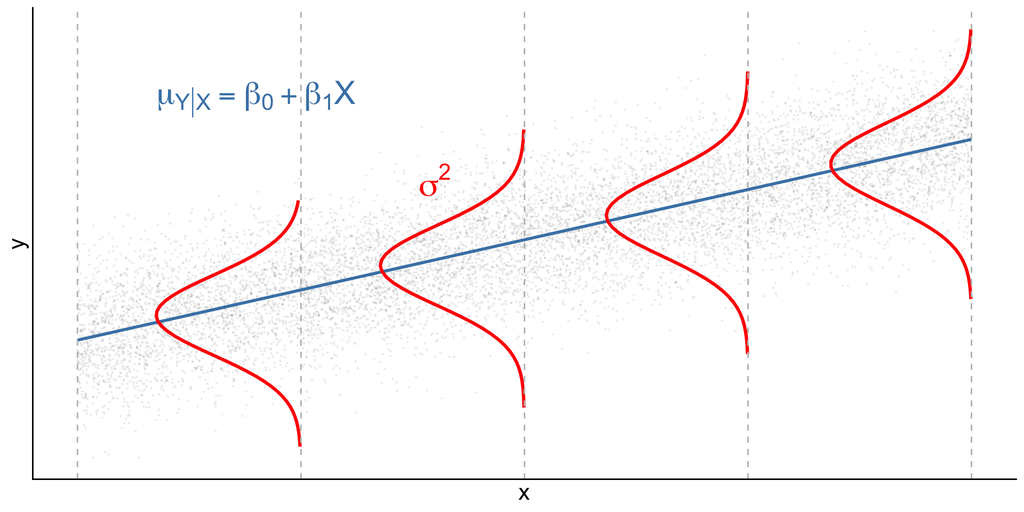

- **L**inearity: Linear relationship between mean of the response $Y$ and the predictor $X$
- **I**ndependence: No connection between how any two points lie above or below the regression line
- **N**ormality: Response, $Y$, follows a normal distribution at each level of the predictor, $X$ (indicated by red curves)
- **E**qual variance: Variance (or standard deviation) of the response, $Y$, is equal for all levels of the predictor, $X$

Modified from Figure 1.1. in BMLR]

## Example

Sea ice data

```r
si <- read_csv("data/seaice.csv")
head(si)
```

```
# A tibble: 6 × 6
   year    mo source_dataset region extent  area
  <dbl> <dbl> <chr>          <chr>   <dbl> <dbl>
1  1979     9 NSIDC-0051     N        7.05  4.58
2  1980     9 NSIDC-0051     N        7.67  4.87
3  1981     9 NSIDC-0051     N        7.14  4.44
4  1982     9 NSIDC-0051     N        7.3   4.43
5  1983     9 NSIDC-0051     N        7.39  4.7
6  1984     9 NSIDC-0051     N        6.81  4.11
```

## Sea ice data information

The National Oceanic and Atmospheric Administration measures the amount of sea ice in both the arctic and antarctic on a regular basis (at least daily).

Our data:

- Average amount of ice for the month of September in the Arctic
- September is the month with the least amount of ice in the Arctic
- Data from 1979 - 2025 (September isn’t over yet so we don’t have 2026 yet)
- Area = the total region covered by ice
- Extent = the total region with at least 15% ice cover (think about a slice of swiss cheese)

## Is the relationship linear?

- Plot
- Code

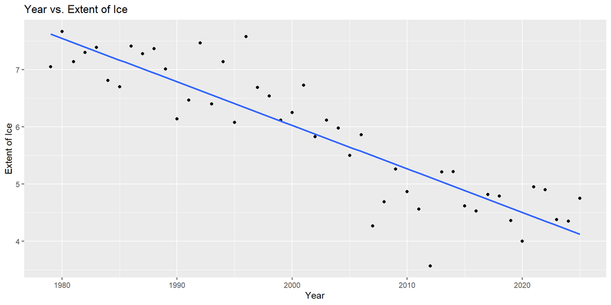

```r
ggplot(data = si, aes(x = year, y = extent)) +
  geom_point() +
  geom_smooth(method = "lm", se = FALSE) +
  labs(x = "Year", y = "Extent of Ice",
       title = "Year vs. Extent of Ice")
```

## Compute the model

- Output
- Code

| term | estimate | std.error | statistic | p.value |
| --- | --- | --- | --- | --- |
| (Intercept) | 158.155 | 11.277 | 14.025 | 0 |
| year | -0.076 | 0.006 | -13.504 | 0 |

```r
# Fit and display model
model1 <- lm(extent ~ year, data=si)
tidy(model1) |> kable(digits = 3)
```

## Interpretation

$$\widehat{extent} = 158.155 - 0.076 ~ year$$

| term | estimate | std.error | statistic | p.value |
| --- | --- | --- | --- | --- |
| (Intercept) | 158.155 | 11.277 | 14.025 | 0 |
| year | -0.076 | 0.006 | -13.504 | 0 |

1. Write out the interpretations for `year`.
2. Does the intercept have a meaningful interpretation?

## Center the data

- Create new variable
- Code
- We only have data starting in 1979. So let’s call that year 0. The data at the beginning of the study.
- Create a new variable: $time = year - 1979$
- This is called centering

```r
# Fit and display model
si |>
  mutate(c_year = year-1979) -> si
```

## Interpret new model

| term | estimate | std.error | statistic | p.value |
| --- | --- | --- | --- | --- |
| (Intercept) | 7.625 | 0.150 | 50.693 | 0 |
| c_year | -0.076 | 0.006 | -13.504 | 0 |

Questions:

- 1. What is the interpretation of the y-intercept now?
- 2. Did the slope change?

## Check assumptions

- Output
- Code

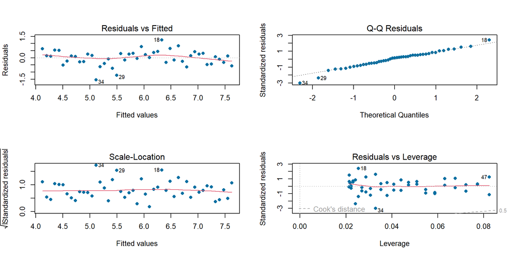

```r
# Plot the diagnostic plots
par(mfrow=c(2,2))

plot(model2, pch=16, col='#006EA1')
```

`pch` defines the shape of the plotted symbol

`col` defines the color of the plotted symbol

## What about the curvature?

Try polynomial regression:

$$y_i = \beta_0 + \beta_1 ~ xi + \beta_2 ~x_i^2 + \beta_3 ~ x_i^3 ... + \beta_d ~ x_i^d + \epsilon_i$$

In this case, maybe a cubic (why?):

$$\widehat{extent} = \hat{\beta}_0 + \hat{\beta}_1 ~ c\_year + \hat{\beta}_2 ~c\_year^2 + \hat{\beta}_3 ~ c\_year^3$$

## New model

- Output
- Code

| term | estimate | std.error | statistic | p.value |
| --- | --- | --- | --- | --- |
| (Intercept) | 5.875 | 0.069 | 85.003 | 0.000 |
| poly(c_year, 3)1 | -7.074 | 0.474 | -14.928 | 0.000 |
| poly(c_year, 3)2 | -0.040 | 0.474 | -0.084 | 0.933 |
| poly(c_year, 3)3 | 1.640 | 0.474 | 3.462 | 0.001 |

```r
# Fit and display model
model3 <- lm(extent ~ poly(c_year,3), data=si)
tidy(model3) |> kable(digits = 3)
```

## Check assumptions

- Output
- Code

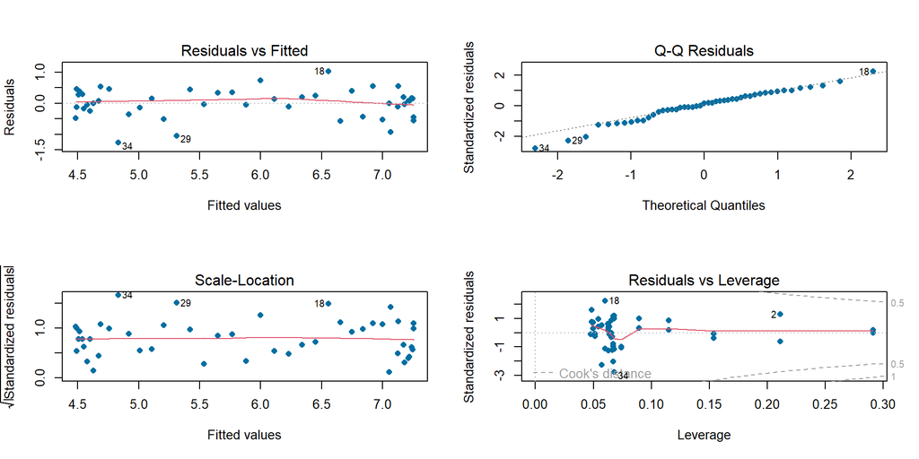

```r
# Plot the diagnostic plots
par(mfrow=c(2,2))

plot(model3, pch=16, col='#006EA1')
```

## Review of multiple linear regression

## Data: Saratoga house prices

Data from homes for sale in Saratoga, NY. The data is about 15 years old.

**Response variable**

- `Price`: Price of the home in 1000s of dollars

**Predictor/Explanatory variables**

- `Size`: Size of the home in 1000s of square feet
- `Baths`: Number of bathrooms
- `Bedrooms`: Number of bedrooms
- `Fireplace`: Does it have a fireplace? 0 = No, 1 = Yes
- `Acres`: Size of the lot in acres
- `Age`: Age of the home

## Data

```r
saratoga <- read_csv("data/saratoga.csv")
```

```r
saratoga |>
  head(5) |> kable()
```

| Price | Size | Baths | Bedrooms | Fireplace | Acres | Age |
| --- | --- | --- | --- | --- | --- | --- |
| 142.212 | 1.982 | 1.0 | 3 | 0 | 2.00 | 133 |
| 134.865 | 1.676 | 1.5 | 3 | 1 | 0.38 | 14 |
| 118.007 | 1.694 | 2.0 | 3 | 1 | 0.96 | 15 |
| 138.297 | 1.800 | 1.0 | 2 | 1 | 0.48 | 49 |
| 129.470 | 2.088 | 1.0 | 3 | 1 | 1.84 | 29 |

## Data Analysis Life Cycle

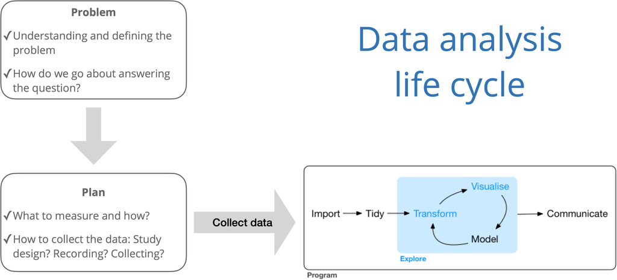

## Exploratory data analysis (EDA)

- Once you’re ready for the statistical analysis (explore), the first step should always be **exploratory data analysis**.
- The EDA will help you
  - begin to understand the variables and observations
  - identify outliers or potential data entry errors
  - begin to see relationships between variables
  - identify the appropriate model and identify a strategy
- The EDA is exploratory; formal modeling and statistical inference should be used to draw conclusions.

## Plots for univariate EDA

- Plot
- Code

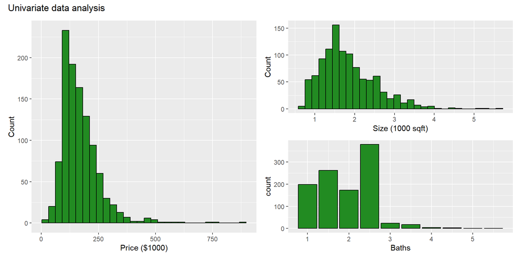

```r
p1 <- ggplot(data = saratoga, aes(x = Price)) +
  geom_histogram(fill = "forestgreen", color = "black") +
  labs(x = "Price ($1000)", y = "Count")

p2 <- ggplot(data = saratoga, aes(x = Size)) +
  geom_histogram(fill = "forestgreen", color = "black") +
  labs(x = "Size (1000 sqft)", y = "Count")

p3 <- ggplot(data = saratoga, aes(x = Baths)) +
   geom_bar(fill = "forestgreen", color = "black", aes(x = ))

p1 + (p2 / p3) +
  plot_annotation(title = "Univariate data analysis")
```

## Plots for univariate EDA (cont.)

- Plot
- Code

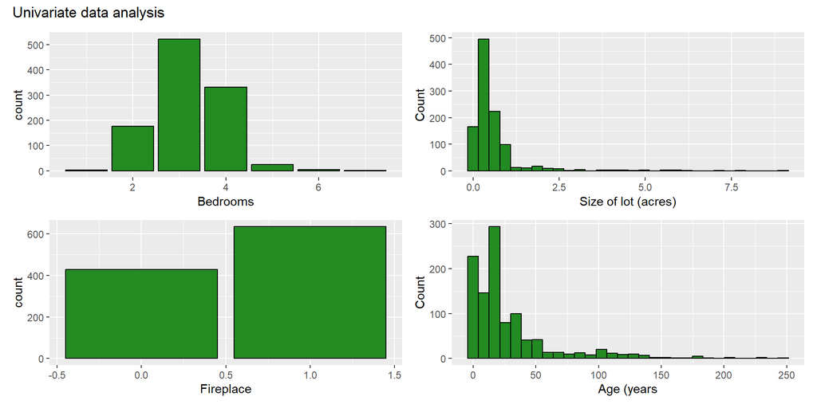

```r
p1 <- ggplot(data = saratoga, aes(x = Bedrooms)) +
  geom_bar(fill = "forestgreen", color = "black", aes(x=))

p2 <- ggplot(data = saratoga, aes(x = Acres)) +
  geom_histogram(fill = "forestgreen", color = "black") +
  labs(x = "Size of lot (acres)", y = "Count")

p3 <- ggplot(data = saratoga, aes(x = Fireplace)) +
   geom_bar(fill = "forestgreen", color = "black", aes(x = ))

p4 <- ggplot(data = saratoga, aes(x = Age)) +
  geom_histogram(fill = "forestgreen", color = "black") +
  labs(x = "Age (years", y = "Count")

(p1 + p2) / (p3 + p4)  +
  plot_annotation(title = "Univariate data analysis")
```

## Plots for bivariate EDA

- Plot
- Code

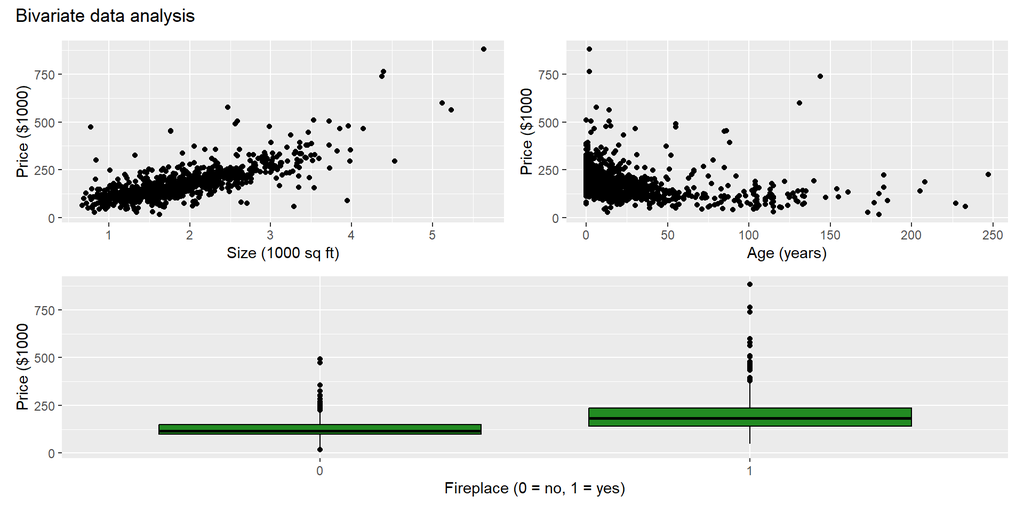

```r
p5 <- ggplot(data = saratoga, aes(x = Size, y = Price)) +
  geom_point() +
  labs(x = "Size (1000 sq ft)", y = "Price ($1000)")

p6 <- ggplot(data = saratoga, aes(x = Age, y = Price)) +
  geom_point() +
  labs(x = "Age (years)", y = "Price ($1000")

p7 <- ggplot(data = saratoga, aes(x = as.factor(Fireplace), y = Price)) +
  geom_boxplot(fill = "forestgreen", color = "black") +
  labs(x = "Fireplace (0 = no, 1 = yes)", y = "Price ($1000")

(p5 + p6) / p7 +
  plot_annotation(title = "Bivariate data analysis")
```

## Scatterplot matrix

A **scatterplot matrix** helps quickly visualize relationships between many variable pairs. They are particularly useful to identify potentially correlated predictors.

- Plot
- Code

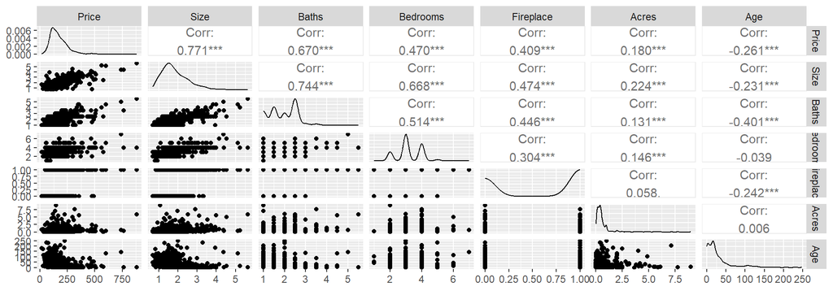

```r
#library(GGally)
ggpairs(data = saratoga)
```

## Plots for multivariate EDA

Plot the relationship between the response and a predictor based on levels of another predictor to assess potential interactions.

- Plot
- Code

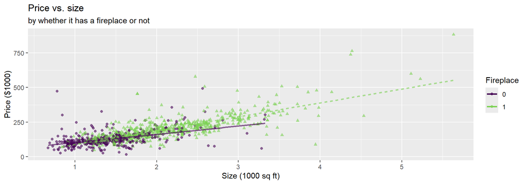

```r
#library(viridis)
saratoga$fire <- as.factor(saratoga$Fireplace)
ggplot(data = saratoga, aes(x = Size, y = Price, color = fire,
                         shape = fire, linetype = fire)) +
  geom_point() +
  geom_smooth(method = "lm", se = FALSE, aes(linetype = fire)) +
  labs(x = "Size (1000 sq ft)", y = "Price ($1000)", color = "Fireplace",
       title = "Price vs. size",
       subtitle = "by whether it has a fireplace or not") +
  guides(lty = FALSE, shape = FALSE) +
  scale_color_viridis_d(alpha = 0.6, end = 0.8)
```

## Model 1: Main effects model

- Output
- Code

| term | estimate | std.error | statistic | p.value |
| --- | --- | --- | --- | --- |
| (Intercept) | 0.950 | 7.562 | 0.126 | 0.900 |
| Size | 80.073 | 4.170 | 19.204 | 0.000 |
| Baths | 25.279 | 3.870 | 6.532 | 0.000 |
| Bedrooms | -9.014 | 2.852 | -3.160 | 0.002 |
| Acres | 1.887 | 2.080 | 0.907 | 0.364 |
| Fireplace | 4.844 | 3.776 | 1.283 | 0.200 |
| Age | -0.064 | 0.051 | -1.244 | 0.214 |

```r
# Fit and display model
pr.model1 <- lm(Price ~ Size + Baths + Bedrooms + Size + Acres + Fireplace + Age, data = saratoga)
tidy(pr.model1) |> kable(digits = 3)
```

## Interpretation

$$\begin{aligned}
\widehat{Price} = & 0.950 + 80.073 ~ Size + 25.279 ~ Baths - 9.014 ~ Bedrooms + 1.887 ~ Acres \\
& + 4.844 ~ Fireplace - 0.064 ~ Age
\end{aligned}$$

| term | estimate |
| --- | --- |
| (Intercept) | 0.950 |
| Size | 80.073 |
| Baths | 25.279 |
| Bedrooms | -9.014 |
| Acres | 1.887 |
| Fireplace | 4.844 |
| Age | -0.064 |

1. Write out the interpretations for `Size` and `Fireplace`.
2. Does the intercept have a meaningful interpretation?

## Model 1: Check model assumptions

- Plots
- Code
- Questions

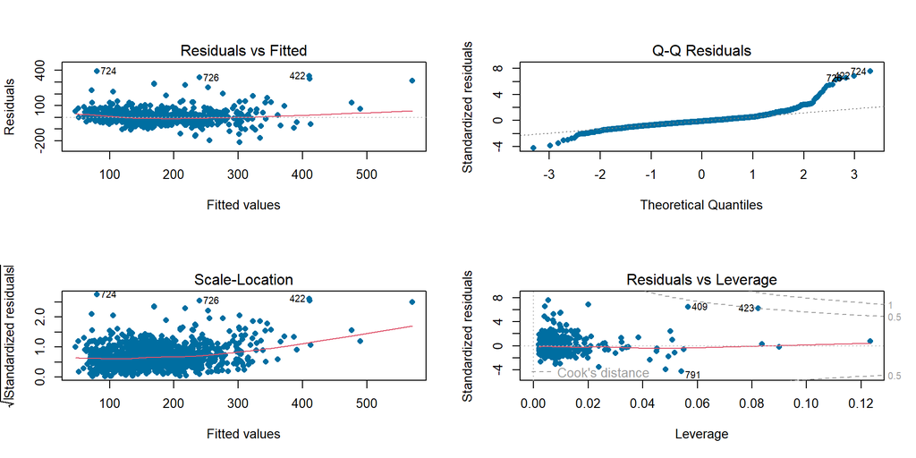

```r
#library(ggfortify)
par(mfrow=c(2,2))

plot(pr.model1, pch=16, col='#006EA1')
```

Which of the model assumptions (LINE) does this pass and/or fail?

## Model 2: Add interaction term for Fireplace and Size?

- Plot
- Code

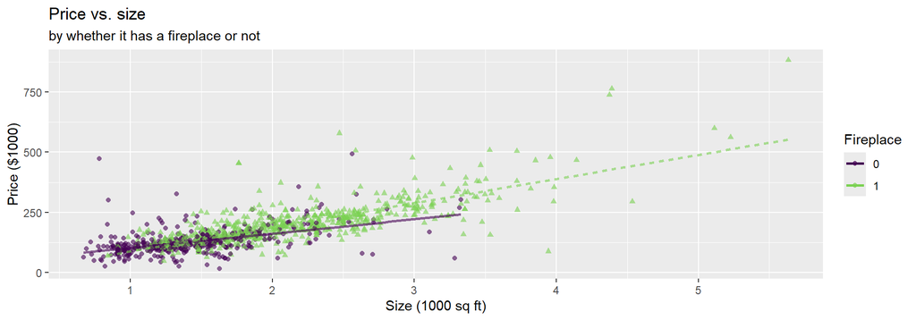

```r
#library(viridis)
#saratoga$fire <- as.factor(saratoga$Fireplace)
ggplot(data = saratoga, aes(x = Size, y = Price, color = fire,
                         shape = fire, linetype = fire)) +
  geom_point() +
  geom_smooth(method = "lm", se = FALSE, aes(linetype = fire)) +
  labs(x = "Size (1000 sq ft)", y = "Price ($1000)", color = "Fireplace",
       title = "Price vs. size",
       subtitle = "by whether it has a fireplace or not") +
  guides(lty = FALSE, shape = FALSE) +
  scale_color_viridis_d(alpha = 0.6, end = 0.8)
```

## Model 2: Add $Fireplace * Size$

- Output
- Code

| term | estimate | std.error | statistic | p.value |
| --- | --- | --- | --- | --- |
| (Intercept) | 45.0000 | 10.0209 | 4.4906 | 0.0000 |
| Size | 48.3306 | 6.3482 | 7.6132 | 0.0000 |
| Baths | 25.7862 | 3.7966 | 6.7919 | 0.0000 |
| Bedrooms | -8.9452 | 2.7976 | -3.1974 | 0.0014 |
| Acres | 2.0120 | 2.0400 | 0.9863 | 0.3242 |
| Fireplace | -59.3043 | 10.4881 | -5.6544 | 0.0000 |
| Age | -0.0518 | 0.0503 | -1.0314 | 0.3026 |
| Size:Fireplace | 40.5109 | 6.1967 | 6.5375 | 0.0000 |

```r
pr.model2 <- lm(Price ~ Size + Baths + Bedrooms + Acres + Fireplace + Age +Fireplace*Size, data = saratoga)
tidy(pr.model2) |> kable(digits = 4)
```

## Interpreting interaction effects with 0/1 variable

$$\begin{aligned}
\hat{y}& = \hat{\beta}_0 + \hat{\beta}_1 ~ x_1 + \hat{\beta}_2 ~ x_2 + \hat{\beta}_3 ~x_3 +\hat{\beta}_4 ~ x_1~x_2\\
& = \hat{\beta}_0 + \hat{\beta}_1 ~ x_1 + \hat{\beta}_3 ~x_3\hspace{3.9 in} \text{ when } x_2=0\\
& = (\hat{\beta}_0 +\hat{\beta}_2) + (\hat{\beta}_1 + \hat{\beta}_4) ~ x_1 +\hat{\beta}_3~x_3\hspace{.75 in} \text{ when } x_2=1
\end{aligned}$$

**General interpretation**: When $x_2$ is present, the slope between $x_1$ and $y$ increases(decreases) by $\hat{\beta}_4$ units and the $y$-intercept increases(decreases) by $\hat{\beta}_2$ units when all other variables are held constant.

$$\begin{aligned}\widehat{Price} = &45.00 + 48.33 ~ Size + 25.79 ~ Baths - 8.95 ~ Bedrooms \\
& + 2.01 ~ Acres - 59.30 ~ Fireplace - 0.05 ~ Age + 40.51~Fireplace * Size\end{aligned}$$

Question:

*Interpret the effect that having a fireplace has on the relationship between size and price.*

## Model 2: Check model assumptions

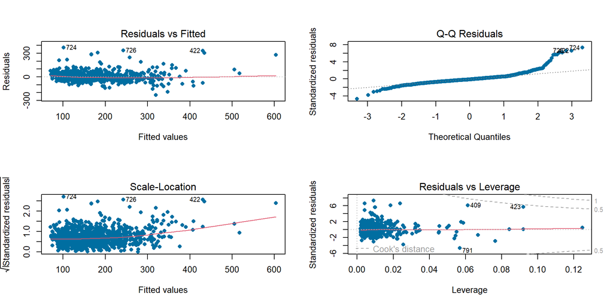

## Model 3: Try ln of response and delete some variables

- Output
- Code

| term | estimate | std.error | statistic | p.value |
| --- | --- | --- | --- | --- |
| (Intercept) | 4.092 | 0.055 | 74.866 | 0.000 |
| Size | 0.306 | 0.035 | 8.694 | 0.000 |
| Baths | 0.177 | 0.020 | 8.906 | 0.000 |
| Bedrooms | -0.013 | 0.015 | -0.850 | 0.396 |
| Fireplace | 0.081 | 0.059 | 1.390 | 0.165 |
| Size:Fireplace | 0.026 | 0.035 | 0.743 | 0.458 |

```r
pr.model3 <- lm(log(Price) ~ Size + Baths + Bedrooms  + Fireplace  + Fireplace*Size, data = saratoga)
tidy(pr.model3) |> kable(digits = 3)
```

## Model 4: Fewer terms yet

- Output
- Code
- Assumptions

| term | estimate | std.error | statistic | p.value |
| --- | --- | --- | --- | --- |
| (Intercept) | 4.026 | 0.028 | 143.310 | 0 |
| Size | 0.344 | 0.019 | 17.817 | 0 |
| Baths | 0.195 | 0.020 | 9.790 | 0 |

```r
pr.model4 <- lm(log(Price) ~ Size + Baths, data = saratoga)
tidy(pr.model4) |> kable(digits = 3)
```

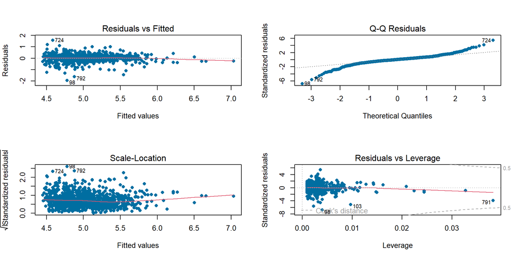

## Which model would you choose?

- Model 1: Main effects
- Model 2: Main effects + interaction
- Model 4: Small model
- Code

| r.squared | adj.r.squared | AIC | BIC |
| --- | --- | --- | --- |
| 0.621 | 0.619 | 11432.1 | 11471.85 |

| r.squared | adj.r.squared | AIC | BIC |
| --- | --- | --- | --- |
| 0.636 | 0.633 | 11391.88 | 11436.6 |

| r.squared | adj.r.squared | AIC | BIC |
| --- | --- | --- | --- |
| 0.587 | 0.586 | 389.812 | 409.687 |

```r
# Model 1
glance(pr.model1) |>
  select(r.squared, adj.r.squared, AIC, BIC) |>
  kable(digits = 3)

# Model2
glance(pr.model2) |>
  select(r.squared, adj.r.squared, AIC, BIC) |>
  kable(digits = 3)

# Model 4
glance(pr.model4) |>
  select(r.squared, adj.r.squared, AIC, BIC) |>
  kable(digits = 3)
```

## What are these model quality metrics?

- **How do we define RSquared?**
- **What is adj.r.squared?**

## Measures of model performance

- $\color{#4187aa}{R^2}$: Proportion of variability in the response explained by the model.
  - Will always increase as predictors are added, so it shouldn’t be used to compare models
- $\color{#4187aa}{Adj. R^2}$: Similar to $R^2$ with a penalty for extra terms
- $\color{#4187aa}{AIC}$: Likelihood-based approach balancing model performance and complexity
- $\color{#4187aa}{BIC}$: Similar to AIC with stronger penalty for extra terms
- **Nested F Test (extra sum of squares F test)**: Generalization of t-test for individual coefficients to perform significance tests on nested models

## Which model would you choose?

Use the **`glance`** function to get model statistics.

- Output
- Code

| model | r.squared | adj.r.squared | AIC | BIC |
| --- | --- | --- | --- | --- |
| Model1 | 0.621 | 0.619 | 11432.097 | 11471.847 |
| Model2 | 0.636 | 0.633 | 11391.883 | 11436.603 |
| Model4 | 0.587 | 0.586 | 389.812 | 409.687 |

```r
model1_glance <- glance(pr.model1) |>
  select(r.squared, adj.r.squared, AIC, BIC)
model2_glance <- glance(pr.model2) |>
  select(r.squared, adj.r.squared, AIC, BIC)
model4_glance <- glance(pr.model4) |>
  select(r.squared, adj.r.squared, AIC, BIC)

model1_glance |>
  bind_rows(model2_glance) |>
  bind_rows(model4_glance) |>
  bind_cols(model = c("Model1", "Model2", "Model4")) |>
  select(model, everything()) |>
kable(digits = 3)
```

## Characteristics of a “good” final model

- Model can be used to answer primary research questions
- Predictor variables control for important covariates
- Potential interactions have been investigated
- Variables are centered, as needed, for more meaningful interpretations
- Unnecessary terms are removed
- Assumptions are met and influential points have been addressed
- Model tells a “persuasive story parsimoniously”

[List from Section 1.6.7 of BMLR](https://bookdown.org/roback/bookdown-BeyondMLR/)

## Inference for multiple linear regression

Use statistical inference to

- Determine if predictors are statistically significant (not necessarily practically significant!)
- Quantify uncertainty in coefficient estimates
- Quantify uncertainty in model predictions

If L.I.N.E. assumptions are met, we can conduct inference using the $t$ distribution and estimated standard errors

## Inference for regression

- When L.I.N.E. conditions are met
- We can

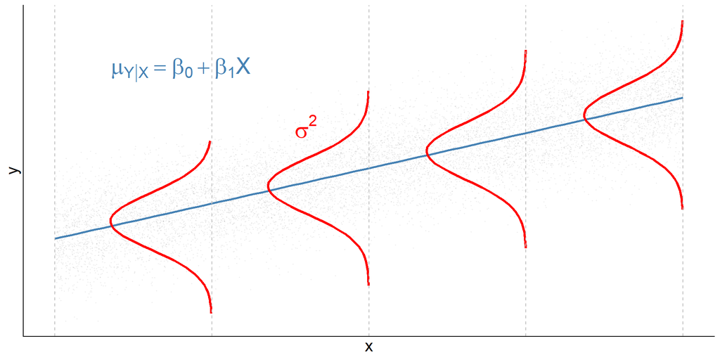

- Use least squares regression to get the estimates $\hat{\beta}_0$, $\hat{\beta}_1$, and $\hat{\sigma}^2$
- $\hat{\sigma}$ is the **regression standard error**
- $\hat{\sigma} = \sqrt{\frac{\sum_{i=1}^n(y_i - \hat{y}_i)^2}{n - p - 1}} = \sqrt{\frac{\sum_{i=1}^n e_i^2}{n-p-1}}$

## Beyond linear regression

- When we use linear least squares regression to draw conclusions, we do so under the assumption that L.I.N.E. are all met.
- **Generalized linear models** require different assumptions and can accommodate violations in L.I.N.E.
  - Relationship between response and predictor(s) can be nonlinear
  - Response variable can be non-normal
  - Variance in response can differ at each level of predictor(s)

**But the independence assumption must hold!**

- **Multilevel models** will be used for data with correlated observations

## Acknowledgements

- These slides are based on content in [BMLR: Chapter 1 - Review of Multiple Linear Regression](https://bookdown.org/roback/bookdown-BeyondMLR/ch-MLRreview.html)
- Initial versions of the slides are by Dr. Maria Tackett, Duke University